# Onlin Retail

James Fang

04/09/2020

## Data proprocessing

```r
library(tidyverse)
retail.df <- read.csv('online_retail_II.csv')
Date <- as.Date(sapply(strsplit(retail.df$InvoiceDate,' '),function(x) x[1]))
retail.df <- data.frame(retail.df,Date)
```

Value = Quantity * Unit Price

```r
retail.df$Value <- retail.df$Quantity* retail.df$Price
```

Volume can be negative due to sales returns, but price normally should be positive. Let’s have a look.

```r
head(retail.df[retail.df$Price <=0 ,])
```

|  | Invoice | StockCode | Description | Quantity | InvoiceDate | Price | Customer.ID | Country | Date | Value |
| --- | --- | --- | --- | --- | --- | --- | --- | --- | --- | --- |
| 264 | 489464 | 21733 | 85123a mixed | -96 | 2009-12-01 10:52:00 | 0 | NA | United Kingdom | 2009-12-01 | 0 |
| 284 | 489463 | 71477 | short | -240 | 2009-12-01 10:52:00 | 0 | NA | United Kingdom | 2009-12-01 | 0 |
| 285 | 489467 | 85123A | 21733 mixed | -192 | 2009-12-01 10:53:00 | 0 | NA | United Kingdom | 2009-12-01 | 0 |
| 471 | 489521 | 21646 |  | -50 | 2009-12-01 11:44:00 | 0 | NA | United Kingdom | 2009-12-01 | 0 |
| 3115 | 489655 | 20683 |  | -44 | 2009-12-01 17:26:00 | 0 | NA | United Kingdom | 2009-12-01 | 0 |
| 3162 | 489659 | 21350 |  | 230 | 2009-12-01 17:39:00 | 0 | NA | United Kingdom | 2009-12-01 | 0 |

It makes sense that these data should be removed no matter for calculating revenue or sales revenue.

```r
retail.df <- retail.df[retail.df$Price >0 ,]
```

Badwords like ?????, damaged,lost, etc. should be removed. By observation, we get the following badwords list.

```r
badwords <- c('?',
'?????',
'back charges',
'bad quality',
'Came as green?',
'Came as green?',
'cant find',
'cant find',
'check',
'checked',
'checked',
'code mix up 72597',
'code mix up 72597',
'coding mix up',
'crushed',
'crushed',
'damaged',
'damaged/dirty',
'damaged?',
'damages',
'damages etc',
'damages, lost bits etc',
'damages?',
'damges',
'Damp and rusty',
'dirty',
'dirty, torn, thrown away.',
'display',
'entry error',
'faulty',
'for show',
'given away',
'gone',
'Gone',
'incorrect credit',
'lost',
'lost in space',
'lost?',
'missing',
'Missing',
'missing (wrongly coded?)',
'missing?',
'missings',
'reverse mistake',
'Rusty ',
'Rusty connections',
'show',
'show display',
'smashed',
'sold in wrong qnty',
'This is a test product.',
'used for show display',
'wet',
'wet & rotting',
'wet and rotting',
'wet cartons',
'wet ctn',
'wet damages',
'Wet, rusty-thrown away',
'wet/smashed/unsellable',
'wrong code',
'wrong ctn size',
'Zebra invcing error')
retail.df$Description[retail.df$Description %in% badwords]
```

```
##  [1] "This is a test product." "This is a test product."
##  [3] "This is a test product." "This is a test product."
##  [5] "This is a test product." "This is a test product."
##  [7] "This is a test product." "This is a test product."
##  [9] "This is a test product." "This is a test product."
## [11] "This is a test product." "This is a test product."
## [13] "This is a test product." "This is a test product."
```

```r
#remove these recoreds
retail.df <- retail.df[!retail.df$Description %in% badwords,]
```

There are 236871 NA value in Customer.ID, we replace NA to 99999

```r
summary(retail.df)
```

```
##    Invoice           StockCode         Description           Quantity
##  Length:1061150     Length:1061150     Length:1061150     Min.   :-80995.0
##  Class :character   Class :character   Class :character   1st Qu.:     1.0
##  Mode  :character   Mode  :character   Mode  :character   Median :     3.0
##                                                           Mean   :    10.3
##                                                           3rd Qu.:    10.0
##                                                           Max.   : 80995.0
##
##  InvoiceDate            Price           Customer.ID       Country
##  Length:1061150     Min.   :    0.00   Min.   :12346    Length:1061150
##  Class :character   1st Qu.:    1.25   1st Qu.:13975    Class :character
##  Mode  :character   Median :    2.10   Median :15257    Mode  :character
##                     Mean   :    4.83   Mean   :15325
##                     3rd Qu.:    4.15   3rd Qu.:16797
##                     Max.   :38970.00   Max.   :18287
##                                        NA's   :236871
##       Date                Value
##  Min.   :2009-12-01   Min.   :-168469.60
##  1st Qu.:2010-07-09   1st Qu.:      3.75
##  Median :2010-12-07   Median :      9.90
##  Mean   :2011-01-02   Mean   :     18.33
##  3rd Qu.:2011-07-22   3rd Qu.:     17.70
##  Max.   :2011-12-09   Max.   : 168469.60
##
```

```r
retail.df$Customer.ID[is.na(retail.df$Customer.ID)] <- 99999
```

## Task I Visualization

### (a)

#### Daily Sales Volume Plot

```r
SalesVolume_byDay <- retail.df %>% group_by(Date) %>% summarize(SalesVolume = sum(Quantity))
```

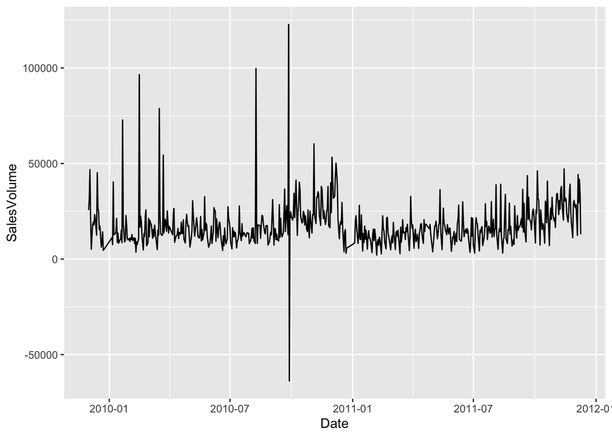

```r
ggplot(SalesVolume_byDay,aes(x=Date,y=SalesVolume)) + geom_line()
```

#### Weekly Sales Volume Plot

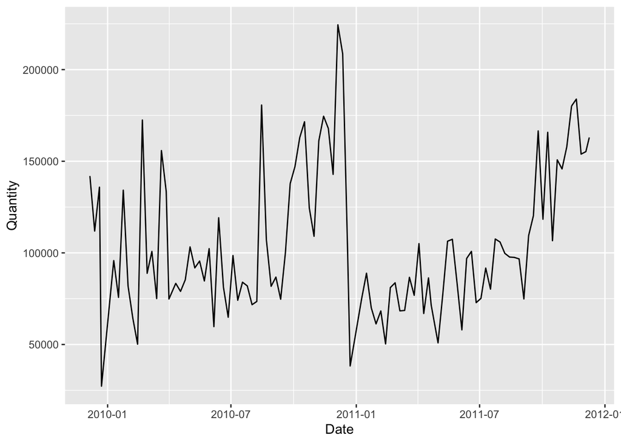

```r
library(tidyquant)
SalesVolume_byWeek <- retail.df %>% tq_transmute(select = Quantity,
                           mutate_fun = apply.weekly,
                           FUN = sum)
ggplot(SalesVolume_byWeek,aes(x=Date, y=Quantity)) + geom_line()
```

#### Monthly Sales Volume Plot

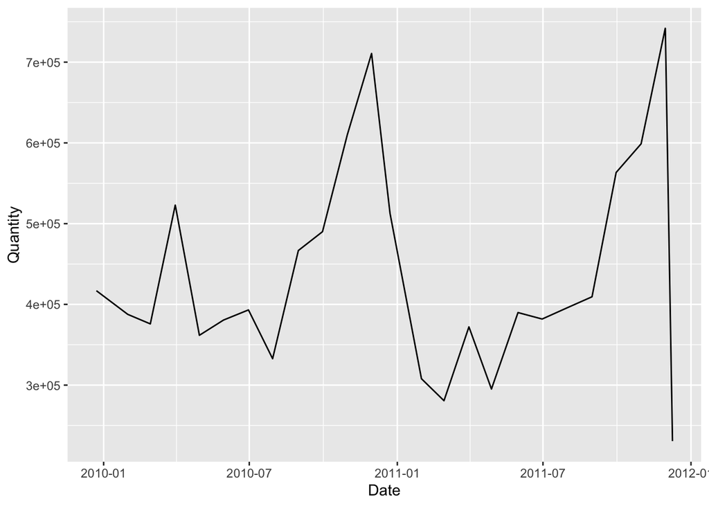

```r
SalesVolume_byMonth <- retail.df %>% tq_transmute(select = Quantity,
                                                 mutate_fun = apply.monthly,
                                                 FUN = sum)
ggplot(SalesVolume_byMonth,aes(x=Date, y=Quantity)) + geom_line()
```

### (b)

#### Plot of Last month’s revenue share by product. We will plot top 10 products which contribute most to revenue share.

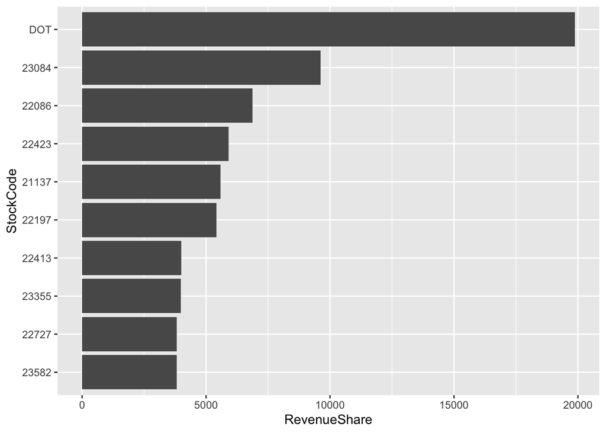

```r
RS_byProduct <- retail.df %>% filter(Date >= "2011-12-01") %>%
          group_by(StockCode) %>%
          summarise(RevenueShare = sum(Value)) %>%
          arrange(desc(RevenueShare))
ggplot(RS_byProduct[1:10,], aes(x = reorder(StockCode,RevenueShare),y = RevenueShare)) +
  geom_col() + coord_flip() + xlab("StockCode")
```

#### Plot of Last month’s revenue share by customer. We will plot top 10 customers which contributes most to revenue share.

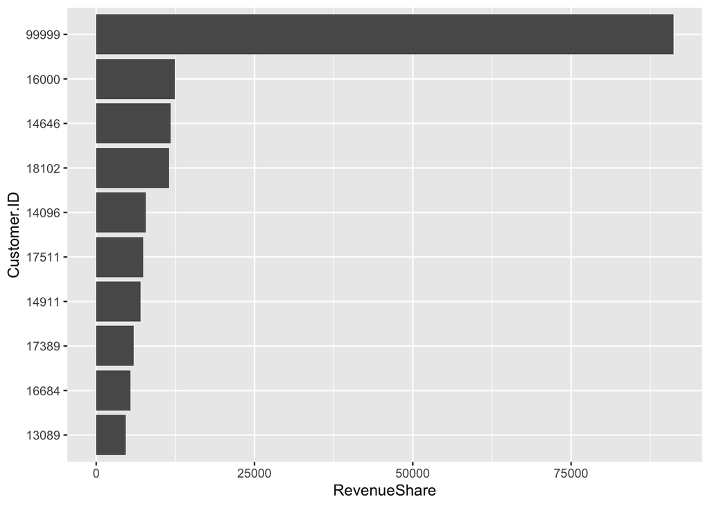

```r
RS_byCustomer <- retail.df %>% filter(Date >= "2011-12-01") %>%
  group_by(Customer.ID) %>%
  summarise(RevenueShare = sum(Value))%>%
  arrange(desc(RevenueShare))
ggplot(RS_byCustomer[1:10,], aes(x = reorder(Customer.ID,RevenueShare),y = RevenueShare)) +
    geom_col() + coord_flip() + xlab("Customer.ID")
```

### (c)

#### Plot of Weighted average monthly sale price by volume

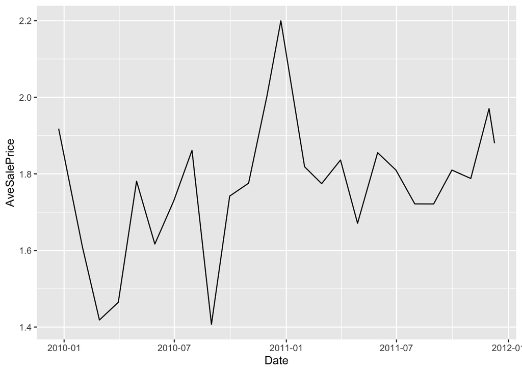

```r
a <- retail.df %>% tq_transmute(select = Value,
                                                  mutate_fun = apply.monthly,
                                                  FUN = sum)
b <- retail.df %>% tq_transmute(select =Quantity ,
                           mutate_fun = apply.monthly,
                           FUN = sum)

SalesVolume_byMonth <- data.frame(Date = a$Date,AveSalePrice = a$Value/b$Quantity)
ggplot(SalesVolume_byMonth,aes(x=Date, y=AveSalePrice)) + geom_line()
```

## Task II Modelling

As being told, there are negative numbers in Quantity. We should drop these values.

```r
retail.df <- retail.df %>% filter(Quantity>0)
```

By observation, there are 3 business weeks in December, and we already have the first week revenue of 12/2011. To get total revenue of this months, we need predict the revenue of the second and third weeks. Let’s draw a time series curve of weekly revenue.

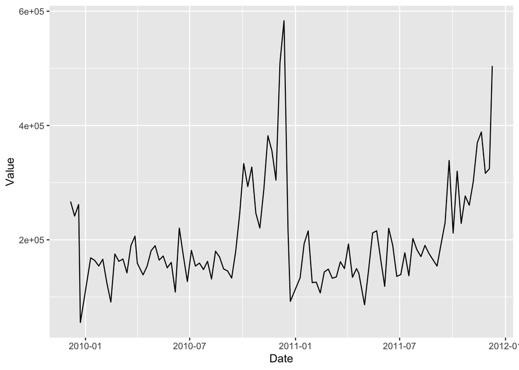

```r
Value_byWeek <- retail.df %>% tq_transmute(select = Value,
                                                 mutate_fun = apply.weekly,
                                                 FUN = sum)
ggplot(Value_byWeek,aes(x=Date, y=Value)) + geom_line()
```

This time series curve looks good to me. We can build a time series model to predict the revenue. We will use modified Holt-Winters’ method to forcast.

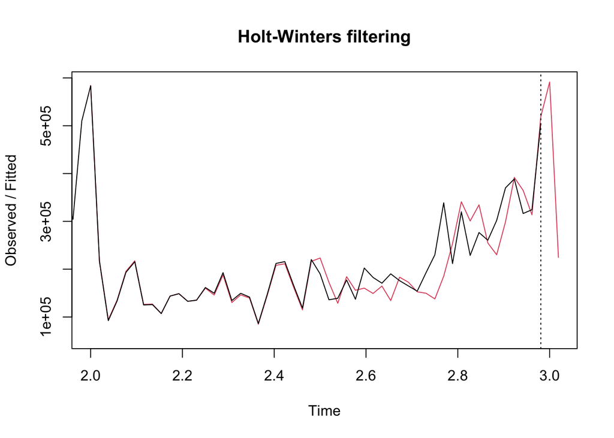

```r
#By observation, there are 52  weeks in a year.
Value_byWeek.ts = ts(Value_byWeek$Value,frequency = 52)
rv.fit  <- HoltWinters(Value_byWeek.ts)
pred <- predict(rv.fit, n.ahead =2 )
plot(rv.fit,pred)
```

```r
pred
```

```
## Time Series:
## Start = c(3, 1)
## End = c(3, 2)
## Frequency = 52
##           fit
## [1,] 591272.6
## [2,] 224595.1
```

Accoording to the prediction plot, the prediction lines are pretty close to the actual line. And We got 2 week’s prediction. We can also put a prediction interval on our plot

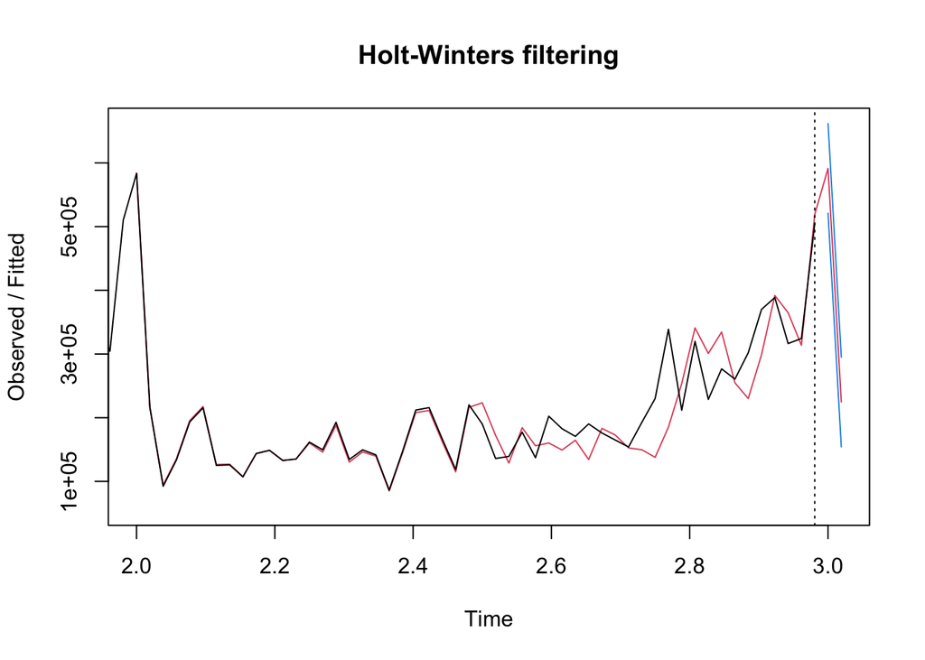

```r
pred.interval <- predict(rv.fit, n.ahead =2 ,prediction.interval = TRUE)
plot(rv.fit,pred.interval)
```

```r
pred.interval
```

```
## Time Series:
## Start = c(3, 1)
## End = c(3, 2)
## Frequency = 52
##               fit      upr      lwr
## 3.000000 591272.6 661561.0 520984.2
## 3.019231 224595.1 294885.2 154305.0
```

Last, we will give the answer of predction of last month’s revenue

```r
Value_byWeek.ts[length(Value_byWeek.ts)] + sum(pred)
```

```
## [1] 1320196
```